# Prospective Models

Brad Stieber

This document contains the four models I have fit as a result of the various variable selection methods we’ve used.

Notice that in our fits using the `lme4` package, we specify a few options in `glmerControl`:

```r
control = glmerControl(
        optimizer = "optimx", calc.derivs = FALSE,
        optCtrl = list(method = "nlminb", starttests = FALSE, kkt = FALSE))
```

These specifications allow for a more performant model fit. Further details can be found in the [`lme4` performance tips vignette](https://cran.r-project.org/web/packages/lme4/vignettes/lmerperf.html).

In each model, we also specify `na.action = na.exclude`, this is so that when we get predicted values from the model object we will get `NA` for observations not used in the model fitting. The default for `na.action` is `na.omit` which means that the predicted values for observations not used in the model fitting will be omitted from the prediction vector. Using `na.exclude` makes it easier to add predicted values to a `data.frame` with incomplete cases.

### Read and Transform Data

```r
library(data.table)
library(lme4)
library(optimx)


wls <- fread("C:/Users/Brad/Desktop/STAT 998/Project 2/WLS2.csv",
             data.table = FALSE)
```

```
##
Read 52.4% of 19095 rows
Read 19095 rows and 310 (of 310) columns from 0.020 GB file in 00:00:04
```

```r
#create variables

#convert doc2004, doc2011, ha2004, ha2011 to binary

wls$doc2004_bin <- ifelse(wls$doc2004 == 'Yes', 1, 0)
wls$doc2011_bin <- ifelse(wls$doc2011 == 'Yes', 1, 0)

wls$ha2004_bin <- ifelse(wls$HA2004 == 'Yes', 1, 0)
wls$ha2011_bin <- ifelse(wls$HA2011 == 'Yes', 1, 0)

#look at age a bit more closely
#fix age
wls$age_2004 <- 2004 - ifelse(is.na(wls$birthyr) & wls$Rtype == 'g', 1938.5,
                              wls$birthyr)

wls$age_2011 <- 2011 - ifelse(is.na(wls$birthyr) & wls$Rtype == 'g', 1938.5,
                              wls$birthyr)

#create relative heart attack variable
wls$HArel2004 <- ifelse(
    wls$HArelless552004 == 'Yes' | wls$HArelmore552004 == 'Yes', 1, 0
    )
#create relative stroke variable
wls$strokefam2004 <- ifelse(
    wls$strokefamless652004 == 'Yes' | wls$strokefammore652004 == 'Yes', 1, 0
    )

#bin troublesleepamt2004
wls$troublesleep04_bin <-
    ifelse(wls$troublesleepamt2004 == 'No',
           'Monthlyorless', wls$troublesleepamt2004)

table(wls$troublesleepamt2004, wls$troublesleep04_bin)
```

```
##
##                 Dailyormore Monthlyorless Onceperweek
##   Dailyormore           967             0           0
##   Monthlyorless           0          2630           0
##   No                      0          4761           0
##   Onceperweek             0             0        2178
```

```r
#create overweight variable
wls$overweight2004 <- ifelse(wls$rightweight2004 == 'Overweight','Yes','No')
table(wls$overweight2004, wls$rightweight2004)
```

```
##
##       Overweight Right weight Underweight
##   No           0         3281         114
##   Yes       6002            0           0
```

```r
#create a weight split variable
rpart::rpart(ha2011_bin ~ mosteverweigh2004, data = wls)
```

```
## n=1753 (17342 observations deleted due to missingness)
##
## node), split, n, deviance, yval
##       * denotes terminal node
##
## 1) root 1753 385.40 0.3263
##   2) mosteverweigh2004< 168.5 328  52.12 0.1982 *
##   3) mosteverweigh2004>=168.5 1425 326.60 0.3558 *
```

```r
wls$weigh2004_split <- ifelse(wls$mosteverweigh2004 < 168.5, 'Under168','Over168')

#create subsets for each response
wls_doc2004.full <- wls[!is.na(wls$doc2004_bin), ]
wls_doc2011.full <- wls[!is.na(wls$doc2011_bin), ]
wls_ha2004.full <- wls[!is.na(wls$ha2004_bin), ]
wls_ha2011.full <- wls[!is.na(wls$ha2011_bin), ]
```

### Create `miss_class` function

This function just calculates the misclassification rate for a binary classifier.

```r
miss_class <- function(preds, actual){

    t_p_a <- table(preds, actual)

    list(
        'Total' = (t_p_a[1,2] + t_p_a[2,1]) / length(actual),
        'PredNoWasYes' = t_p_a[1,2] / (sum(t_p_a[1,])),
        'PredYesWasNo' = t_p_a[2,1] / (sum(t_p_a[2,]))
    )

}
```

### Model for `doc2004`

```r
doc2004_glm <- glmer(
    doc2004_bin ~ sex  + age_2004 + Rtype + THI2004 +
        BMI2004 + highbp2004 + diabetes2004 + stroke2004 +
        smokpkyrs2004 + highchol2004 + highcholfam2004 +
        HArelless552004 +
        sumdepressionindex2004 + alcoholdays2004 +
        troublesleep04_bin + (1|idpub),
    data = wls_doc2004.full, family = 'binomial',
    control = glmerControl(
        optimizer = "optimx", calc.derivs = FALSE,
        optCtrl = list(method = "nlminb", starttests = FALSE, kkt = FALSE)),
    na.action = na.exclude
)

summary(doc2004_glm)
```

```
## Generalized linear mixed model fit by maximum likelihood (Laplace
##   Approximation) [glmerMod]
##  Family: binomial  ( logit )
## Formula:
## doc2004_bin ~ sex + age_2004 + Rtype + THI2004 + BMI2004 + highbp2004 +
##     diabetes2004 + stroke2004 + smokpkyrs2004 + highchol2004 +
##     highcholfam2004 + HArelless552004 + sumdepressionindex2004 +
##     alcoholdays2004 + troublesleep04_bin + (1 | idpub)
##    Data: wls_doc2004.full
## Control:
## glmerControl(optimizer = "optimx", calc.derivs = FALSE, optCtrl = list(method = "nlminb",
##     starttests = FALSE, kkt = FALSE))
##
##      AIC      BIC   logLik deviance df.resid
##     5832     5958    -2898     5796     8157
##
## Scaled residuals:
##    Min     1Q Median     3Q    Max
## -2.549 -0.414 -0.284 -0.179 10.467
##
## Random effects:
##  Groups Name        Variance Std.Dev.
##  idpub  (Intercept) 9.53e-11 9.76e-06
## Number of obs: 8175, groups:  idpub, 6284
##
## Fixed effects:
##                                 Estimate Std. Error z value Pr(>|z|)
## (Intercept)                     -9.09688    0.69750  -13.04  < 2e-16 ***
## sexMale                          0.91694    0.07387   12.41  < 2e-16 ***
## age_2004                         0.07803    0.00911    8.56  < 2e-16 ***
## Rtypes                          -0.03789    0.07197   -0.53  0.59853
## THI2004                          0.04110    0.04101    1.00  0.31630
## BMI2004                          0.02630    0.00709    3.71  0.00021 ***
## highbp2004Yes                    0.43212    0.07377    5.86  4.7e-09 ***
## diabetes2004Yes                  0.59707    0.08936    6.68  2.4e-11 ***
## stroke2004Yes                    1.33985    0.14699    9.12  < 2e-16 ***
## smokpkyrs2004                    0.00792    0.00116    6.83  8.6e-12 ***
## highchol2004Yes                  0.76722    0.07446   10.30  < 2e-16 ***
## highcholfam2004Yes               0.33049    0.07132    4.63  3.6e-06 ***
## HArelless552004Yes               0.52049    0.08394    6.20  5.6e-10 ***
## sumdepressionindex2004           0.00518    0.00238    2.18  0.02930 *
## alcoholdays2004                 -0.01357    0.00371   -3.65  0.00026 ***
## troublesleep04_binMonthlyorless -0.44937    0.11428   -3.93  8.4e-05 ***
## troublesleep04_binOnceperweek   -0.29330    0.12486   -2.35  0.01883 *
## ---
## Signif. codes:  0 '***' 0.001 '**' 0.01 '*' 0.05 '.' 0.1 ' ' 1
## convergence code: 1
```

```r
miss_class(p <- predict(doc2004_glm, type = 'response') >= .5,
           wls_doc2004.full$doc2004_bin)
```

```
## $Total
## [1] 0.09972
##
## $PredNoWasYes
## [1] 0.133
##
## $PredYesWasNo
## [1] 0.3974
```

**This model was fit on 71% of the “good” data.**

### Model for `doc2011`

```r
doc2011_glm <- glmer(formula = doc2011_bin ~ sex + age_2011 + Rtype + THI2011 +
                               BMI2011 +
                               highbp2011 + smokpkyrs2004 + diabetes2011 +
                               alcoholdays2011 + mosteverweigh2011 + HArelless552004 +                                           highcholfam2004 + highchol2011 + stroke2011 +                                                     sumdepressionindex2011 + (1 | idpub),
                  family = "binomial", data = wls_doc2011.full,
                  control = glmerControl(
                      optimizer = "optimx", calc.derivs = FALSE,
                      optCtrl = list(method = "nlminb", starttests = FALSE, kkt = FALSE)),
                  na.action = na.exclude)

summary(doc2011_glm)
```

```
## Generalized linear mixed model fit by maximum likelihood (Laplace
##   Approximation) [glmerMod]
##  Family: binomial  ( logit )
## Formula:
## doc2011_bin ~ sex + age_2011 + Rtype + THI2011 + BMI2011 + highbp2011 +
##     smokpkyrs2004 + diabetes2011 + alcoholdays2011 + mosteverweigh2011 +
##     HArelless552004 + highcholfam2004 + highchol2011 + stroke2011 +
##     sumdepressionindex2011 + (1 | idpub)
##    Data: wls_doc2011.full
## Control:
## glmerControl(optimizer = "optimx", calc.derivs = FALSE, optCtrl = list(method = "nlminb",
##     starttests = FALSE, kkt = FALSE))
##
##      AIC      BIC   logLik deviance df.resid
##     5853     5967    -2909     5819     5999
##
## Scaled residuals:
##    Min     1Q Median     3Q    Max
## -1.776 -0.552 -0.397 -0.216  5.677
##
## Random effects:
##  Groups Name        Variance Std.Dev.
##  idpub  (Intercept) 4.36e-11 6.6e-06
## Number of obs: 6016, groups:  idpub, 4923
##
## Fixed effects:
##                        Estimate Std. Error z value Pr(>|z|)
## (Intercept)            -8.44263    0.74365  -11.35  < 2e-16 ***
## sexMale                 0.67467    0.08397    8.03  9.4e-16 ***
## age_2011                0.07098    0.00914    7.77  8.1e-15 ***
## Rtypes                 -0.05218    0.06966   -0.75  0.45382
## THI2011                 0.00680    0.04391    0.15  0.87691
## BMI2011                -0.00837    0.01000   -0.84  0.40256
## highbp2011Yes           0.39426    0.07393    5.33  9.7e-08 ***
## smokpkyrs2004           0.00491    0.00123    3.98  6.9e-05 ***
## diabetes2011Yes         0.35901    0.08524    4.21  2.5e-05 ***
## alcoholdays2011        -0.00950    0.00324   -2.94  0.00332 **
## mosteverweigh2011       0.00514    0.00141    3.66  0.00025 ***
## HArelless552004Yes      0.38343    0.08663    4.43  9.6e-06 ***
## highcholfam2004Yes      0.20907    0.06892    3.03  0.00242 **
## highchol2011Yes         0.60396    0.07112    8.49  < 2e-16 ***
## stroke2011Yes           0.84733    0.13129    6.45  1.1e-10 ***
## sumdepressionindex2011  0.00680    0.00216    3.15  0.00164 **
## ---
## Signif. codes:  0 '***' 0.001 '**' 0.01 '*' 0.05 '.' 0.1 ' ' 1
## convergence code: 1
```

```r
miss_class(p <- predict(doc2011_glm, type = 'response') >= .5,
           wls_doc2011.full$doc2011_bin)
```

```
## $Total
## [1] 0.1405
##
## $PredNoWasYes
## [1] 0.2076
##
## $PredYesWasNo
## [1] 0.3887
```

**This model was fit on 64.4% of the “good” data.**

### Model for `ha2004`

```r
ha2004_glm <-
    glmer(ha2004_bin ~ sex + age_2004 + Rtype + THI2004  +
              BMI2004 +
              alcoholdays2004 +
              highchol2004 + stressmakepos2004 +
              diabetes2004 + overweight2004 + smokpkyrs2004 + (1|idpub),
          data = wls_ha2004.full, family = 'binomial',
          control = glmerControl(
              optimizer = "optimx", calc.derivs = FALSE,
              optCtrl = list(method = "nlminb", starttests = FALSE, kkt = FALSE)),
          na.action = na.exclude)

summary(ha2004_glm)
```

```
## Generalized linear mixed model fit by maximum likelihood (Laplace
##   Approximation) [glmerMod]
##  Family: binomial  ( logit )
## Formula:
## ha2004_bin ~ sex + age_2004 + Rtype + THI2004 + BMI2004 + alcoholdays2004 +
##     highchol2004 + stressmakepos2004 + diabetes2004 + overweight2004 +
##     smokpkyrs2004 + (1 | idpub)
##    Data: wls_ha2004.full
## Control:
## glmerControl(optimizer = "optimx", calc.derivs = FALSE, optCtrl = list(method = "nlminb",
##     starttests = FALSE, kkt = FALSE))
##
##      AIC      BIC   logLik deviance df.resid
##     1522     1588     -748     1496     1175
##
## Scaled residuals:
##    Min     1Q Median     3Q    Max
## -1.636 -0.784 -0.562  1.045  2.839
##
## Random effects:
##  Groups Name        Variance Std.Dev.
##  idpub  (Intercept) 3.88e-12 1.97e-06
## Number of obs: 1188, groups:  idpub, 1132
##
## Fixed effects:
##                   Estimate Std. Error z value Pr(>|z|)
## (Intercept)       -2.57908    1.29208   -2.00  0.04593 *
## sexMale            0.62639    0.13925    4.50  6.8e-06 ***
## age_2004           0.02938    0.01672    1.76  0.07890 .
## Rtypes             0.00936    0.13424    0.07  0.94440
## THI2004           -0.07520    0.07739   -0.97  0.33119
## BMI2004           -0.01348    0.01463   -0.92  0.35676
## alcoholdays2004   -0.02135    0.00695   -3.07  0.00213 **
## highchol2004Yes    0.64197    0.14236    4.51  6.5e-06 ***
## stressmakepos2004 -0.12878    0.07358   -1.75  0.08011 .
## diabetes2004Yes    0.29176    0.14842    1.97  0.04933 *
## overweight2004Yes  0.37059    0.16581    2.24  0.02541 *
## smokpkyrs2004      0.00690    0.00204    3.37  0.00074 ***
## ---
## Signif. codes:  0 '***' 0.001 '**' 0.01 '*' 0.05 '.' 0.1 ' ' 1
```

[output cut: 11 more lines]

```
## dibts2004Ys  0.095 -0.062 -0.060  0.015 -0.006 -0.229  0.087  0.023  0.022
## ovrwgh2004Y  0.032  0.109  0.070  0.022 -0.026 -0.545 -0.037 -0.075  0.041
## smkpkyr2004 -0.047 -0.059  0.012  0.039  0.062 -0.065 -0.045 -0.044  0.050
##             d2004Y o2004Y
## sexMale
## age_2004
## Rtypes
## THI2004
## BMI2004
## alchldy2004
## hghchl2004Y
## strssmk2004
## dibts2004Ys
## ovrwgh2004Y  0.029
## smkpkyr2004 -0.033 -0.009
```

```r
miss_class(p <- predict(ha2004_glm, type = 'response') >= .5,
           wls_ha2004.full$ha2004_bin)
```

```
## $Total
## [1] 0.2501
##
## $PredNoWasYes
## [1] 0.3393
##
## $PredYesWasNo
## [1] 0.4245
```

**This model was fit on 70.1% of the “good” data.**

### Model for `ha2011`

```r
ha2011_glm <-
    glmer(ha2011_bin ~ sex + age_2011 + Rtype + THI2011 + BMI2011 +
            diabetes2004 + compareAmerica2004 + smokpkyrs2011 +
             alcoholdays2011 + highchol2011 + smokpkyrs2011 +
              HArelless552004 + (1 | idpub),
                    data = wls_ha2011.full,
                    family = 'binomial',
                    control = glmerControl(
                        optimizer = "optimx", calc.derivs = FALSE,
                        optCtrl = list(method = "nlminb", starttests = FALSE, kkt = FALSE)),
                    na.action = na.exclude)

summary(ha2011_glm)
```

```
## Generalized linear mixed model fit by maximum likelihood (Laplace
##   Approximation) [glmerMod]
##  Family: binomial  ( logit )
## Formula:
## ha2011_bin ~ sex + age_2011 + Rtype + THI2011 + BMI2011 + diabetes2004 +
##     compareAmerica2004 + smokpkyrs2011 + alcoholdays2011 + highchol2011 +
##     smokpkyrs2011 + HArelless552004 + (1 | idpub)
##    Data: wls_ha2011.full
## Control:
## glmerControl(optimizer = "optimx", calc.derivs = FALSE, optCtrl = list(method = "nlminb",
##     starttests = FALSE, kkt = FALSE))
##
##      AIC      BIC   logLik deviance df.resid
##   1587.2   1654.8   -780.6   1561.2     1336
##
## Scaled residuals:
##    Min     1Q Median     3Q    Max
## -2.022 -0.666 -0.516  1.094  2.881
##
## Random effects:
##  Groups Name        Variance Std.Dev.
##  idpub  (Intercept) 2.23e-12 1.49e-06
## Number of obs: 1349, groups:  idpub, 1286
##
## Fixed effects:
##                    Estimate Std. Error z value Pr(>|z|)
## (Intercept)        -2.21233    1.43622   -1.54   0.1235
## sexMale             0.80712    0.13791    5.85  4.8e-09 ***
## age_2011            0.02276    0.01769    1.29   0.1982
## Rtypes             -0.04000    0.13275   -0.30   0.7632
## THI2011            -0.10680    0.08275   -1.29   0.1969
## BMI2011            -0.00651    0.01135   -0.57   0.5665
## diabetes2004Yes     0.34902    0.15596    2.24   0.0252 *
## compareAmerica2004 -0.10651    0.04526   -2.35   0.0186 *
## smokpkyrs2011       0.00507    0.00195    2.59   0.0095 **
## alcoholdays2011    -0.01322    0.00612   -2.16   0.0307 *
## highchol2011Yes     0.60774    0.14126    4.30  1.7e-05 ***
## HArelless552004Yes  0.33988    0.14772    2.30   0.0214 *
## ---
## Signif. codes:  0 '***' 0.001 '**' 0.01 '*' 0.05 '.' 0.1 ' ' 1
```

[output cut: 12 more lines]

```
## hghchl2011Y -0.075  0.047  0.024 -0.039 -0.013 -0.083  0.008  0.014  0.013
## HArl552004Y -0.055  0.023  0.042 -0.003 -0.004 -0.043 -0.004  0.025  0.026
##             al2011 h2011Y
## sexMale
## age_2011
## Rtypes
## THI2011
## BMI2011
## dibts2004Ys
## cmprAmr2004
## smkpkyr2011
## alchldy2011
## hghchl2011Y -0.038
## HArl552004Y -0.013 -0.020
## convergence code: 1
```

```r
miss_class(p <- predict(ha2011_glm, type = 'response') >= .5,
           wls_ha2011.full$ha2011_bin)
```

```
## $Total
## [1] 0.1852
##
## $PredNoWasYes
## [1] 0.288
##
## $PredYesWasNo
## [1] 0.5109
```

**This model was fit on 61.1% of the “good” data.**

### Results from all four regressions

```
##
## Calls:
## : [1] "Signif. codes:  0 '***' 0.001 '**' 0.01 '*' 0.05 '.' 0.1 ' ' 1"
##
## ===============================================================================
##                                    DOC 2004    HA 2004   DOC 2011    HA 2011
## -------------------------------------------------------------------------------
##   (Intercept)                      -9.097***  -2.579*    -8.443***  -2.212
##                                    (0.697)    (1.292)    (0.744)    (1.436)
##   sexMale                           0.917***   0.626***   0.675***   0.807***
##                                    (0.074)    (0.139)    (0.084)    (0.138)
##   age_2004                          0.078***   0.029
##                                    (0.009)    (0.017)
##   Rtypes                           -0.038      0.009     -0.052     -0.040
##                                    (0.072)    (0.134)    (0.070)    (0.133)
##   THI2004                           0.041     -0.075
##                                    (0.041)    (0.077)
##   BMI2004                           0.026***  -0.013
##                                    (0.007)    (0.015)
##   highbp2004Yes                     0.432***
##                                    (0.074)
##   diabetes2004Yes                   0.597***   0.292*                0.349*
##                                    (0.089)    (0.148)               (0.156)
##   stroke2004Yes                     1.340***
##                                    (0.147)
##   smokpkyrs2004                     0.008***   0.007***   0.005***
##                                    (0.001)    (0.002)    (0.001)
##   highchol2004Yes                   0.767***   0.642***
##                                    (0.074)    (0.142)
##   highcholfam2004Yes                0.330***              0.209**
##                                    (0.071)               (0.069)
##   HArelless552004Yes                0.520***              0.383***   0.340*
##                                    (0.084)               (0.087)    (0.148)
##   sumdepressionindex2004            0.005*
##                                    (0.002)
##   alcoholdays2004                  -0.014***  -0.021**
##                                    (0.004)    (0.007)
##   troublesleep04_binMonthlyorless  -0.449***
##                                    (0.114)
##   troublesleep04_binOnceperweek    -0.293*
```

[output cut: 22 more lines]

```
##                                                          (0.071)    (0.141)
##   stroke2011Yes                                           0.847***
##                                                          (0.131)
##   sumdepressionindex2011                                  0.007**
##                                                          (0.002)
##   compareAmerica2004                                                -0.107*
##                                                                     (0.045)
##   smokpkyrs2011                                                      0.005**
##                                                                     (0.002)
## -------------------------------------------------------------------------------
##   Log-likelihood                   -2897.98    -748.03   -2909.43    -780.58
##   AIC                               5831.96    1522.05    5852.86    1587.15
##   BIC                               5958.12    1588.09    5966.80    1654.85
##   N                                 8175       1188       6016       1349
## ===============================================================================
```

### Create ROC curves

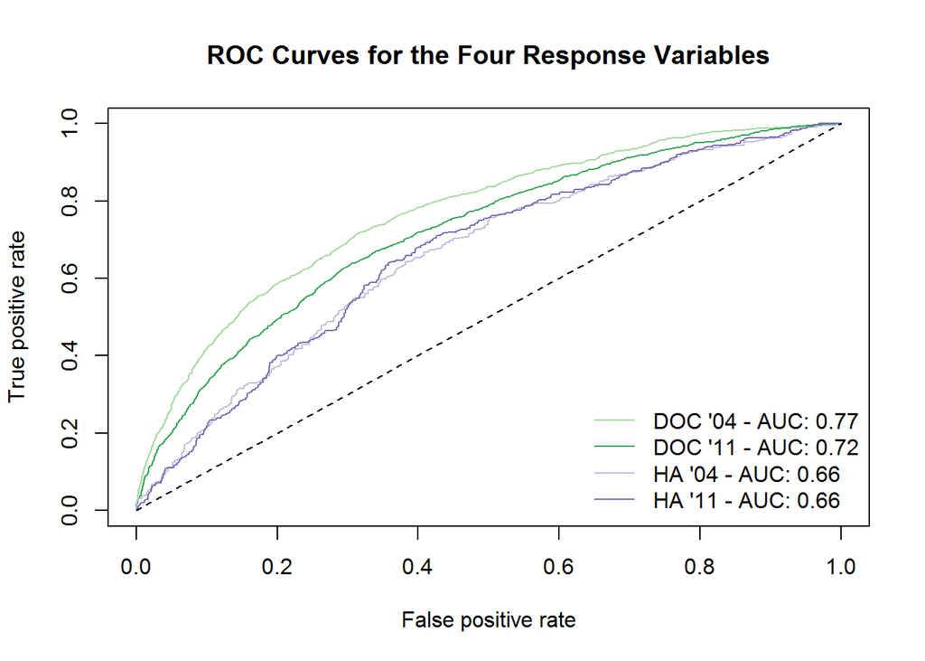